# Red Wine Quality by Fares Badr

##### Let’s plot the histogram of fixed acid + citric acid (tartaric_citric):

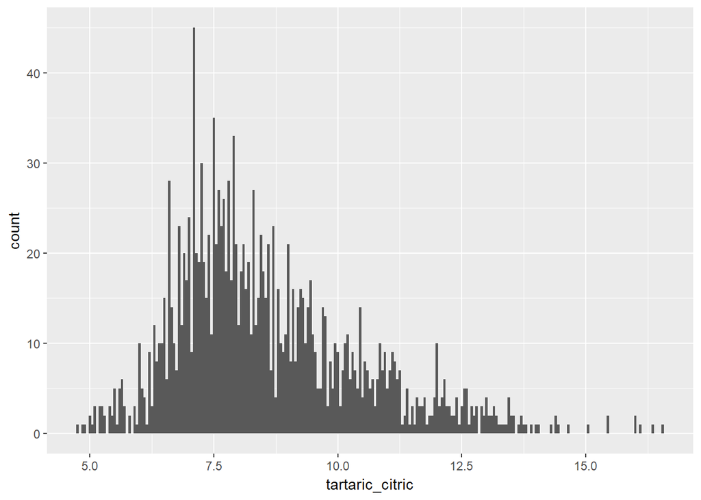

the distribution is long tailed, applying the log scale on the x-axis.

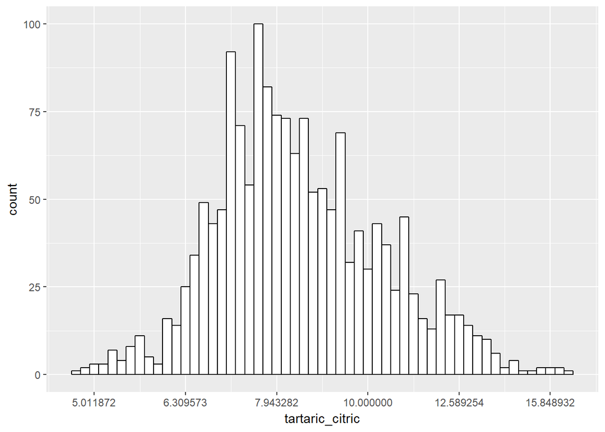

```
##    Min. 1st Qu.  Median    Mean 3rd Qu.    Max.
##   4.750   7.240   8.170   8.591   9.560  16.550
```

With the log scale the distribution looks much better it tend to be symmetric with most of the observations between 6.8 and 9 g/dm^3.

##### Let’s check the residual sugar distribution:

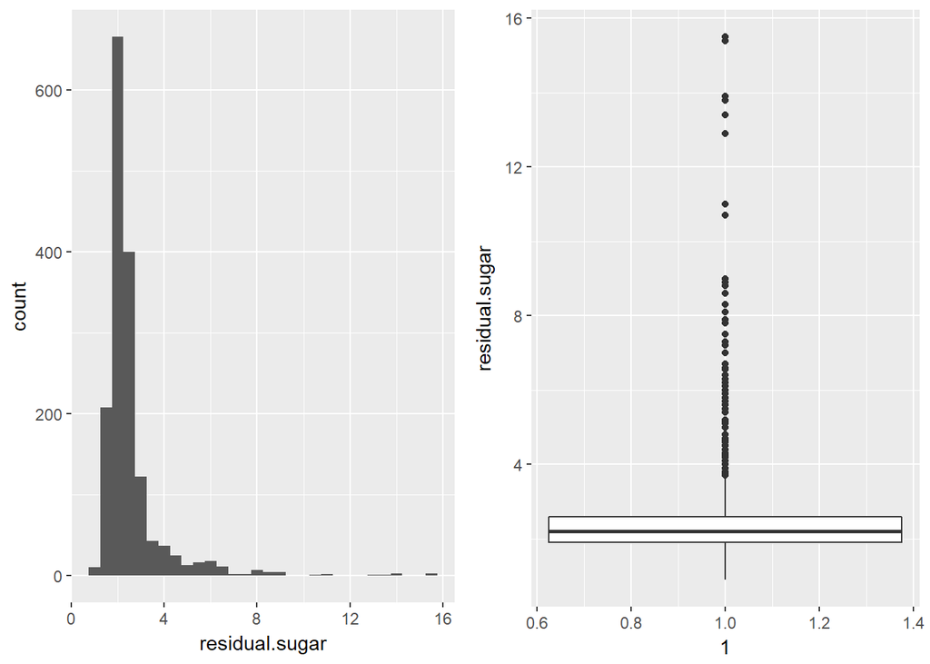

```
##    Min. 1st Qu.  Median    Mean 3rd Qu.    Max.
##   0.900   1.900   2.200   2.539   2.600  15.500
```

residual.sugar distribution is long tailed with clear outliers, transforming the x-axis with log10 and looking at the data the residual.sugar still look positively skewed.

##### Thus we can try to zoom in at the data the get rid of the outliers:

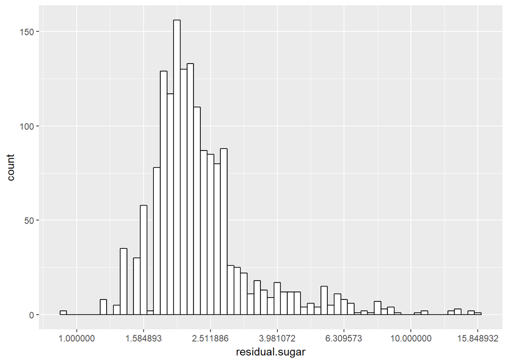

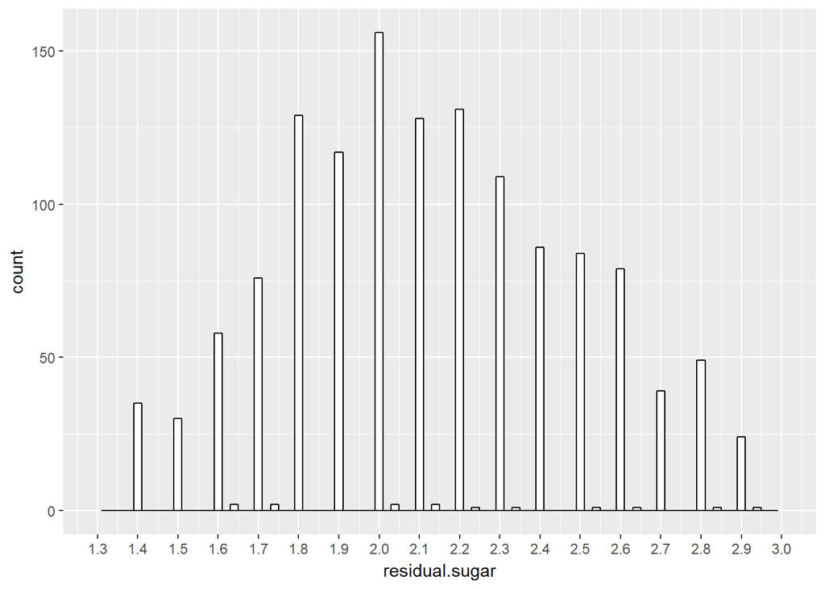

We can see see the peak around 2 g/dm^3 with the data concentrated between 1.7 and 2.4 g/dm^3. It looks like most of the measurments were taken and rounded to 1 decimal digits.

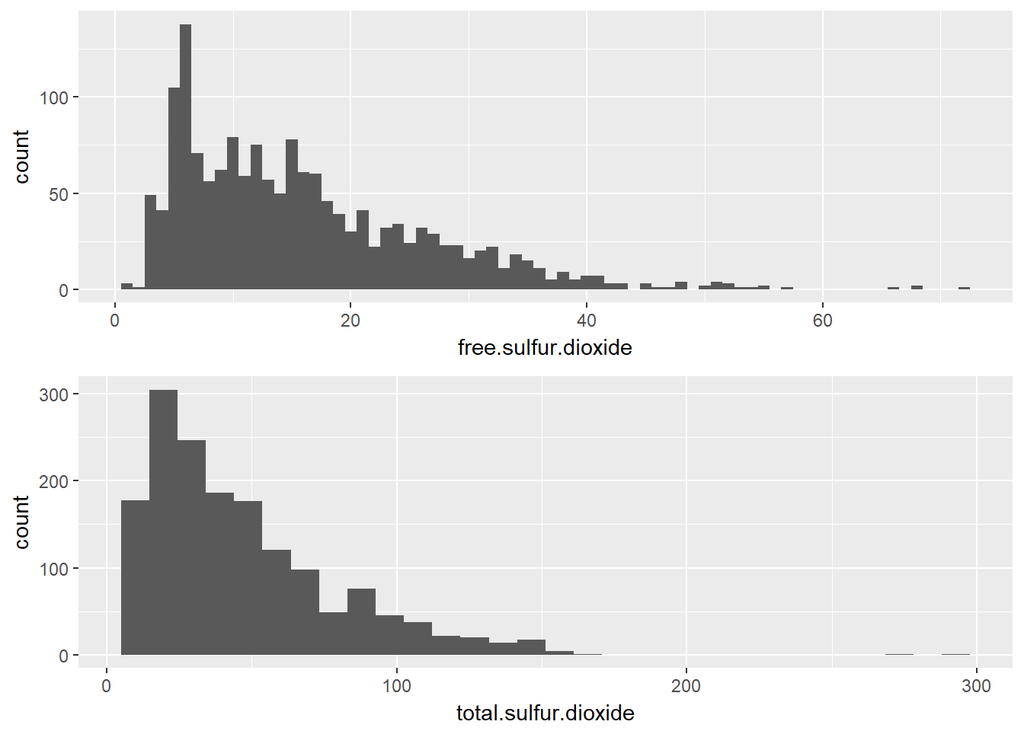

```
## [1] "free.sulfur.dioxide"
```

```
##    Min. 1st Qu.  Median    Mean 3rd Qu.    Max.
##    1.00    7.00   14.00   15.87   21.00   72.00
```

```
## [1] "total.sulfur.dioxide"
```

```
##    Min. 1st Qu.  Median    Mean 3rd Qu.    Max.
##    6.00   22.00   38.00   46.47   62.00  289.00
```

Free SO2 and Total SO2 both have long tailed distribution with clear outliers

##### Below chlorides free SO2, total SO2 histograms after rescaling with log10:

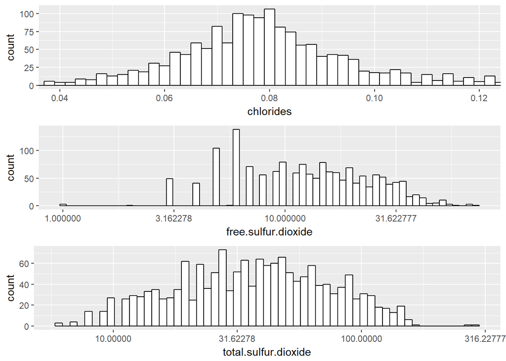

for Free SO2 the peak is round 5 to 6 g/dm^3, it looks the distribution is still positively skewed even after zooming in to eliminate outliers or rescaling with log10.

Chlorides takes an approximately symmetric shape.

###### Let’s look at pH, density and sulphates distributions:

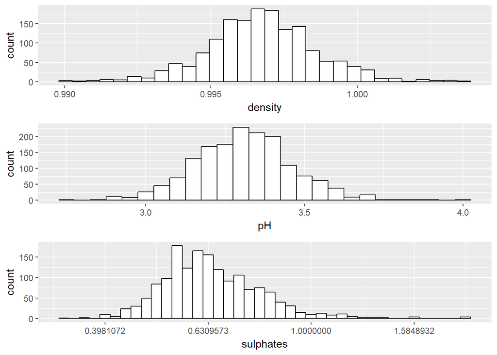

```
## [1] "density"
```

```
##    Min. 1st Qu.  Median    Mean 3rd Qu.    Max.
##  0.9901  0.9956  0.9968  0.9967  0.9978  1.0037
```

```
## [1] "pH"
```

```
##    Min. 1st Qu.  Median    Mean 3rd Qu.    Max.
##   2.740   3.210   3.310   3.311   3.400   4.010
```

```
##
## 2.74 2.86 2.87 2.88 2.89  2.9 2.92 2.93 2.94 2.95 2.98 2.99    3 3.01 3.02
##    1    1    1    2    4    1    4    3    4    1    5    2    6    5    8
## 3.03 3.04 3.05 3.06 3.07 3.08 3.09  3.1 3.11 3.12 3.13 3.14 3.15 3.16 3.17
##    6   10    8   10   11   11   11   19    9   20   13   21   34   36   27
## 3.18 3.19  3.2 3.21 3.22 3.23 3.24 3.25 3.26 3.27 3.28 3.29  3.3 3.31 3.32
##   30   25   39   36   39   32   29   26   53   35   42   46   57   39   45
## 3.33 3.34 3.35 3.36 3.37 3.38 3.39  3.4 3.41 3.42 3.43 3.44 3.45 3.46 3.47
##   37   43   39   56   37   48   48   37   34   33   17   29   20   22   21
## 3.48 3.49  3.5 3.51 3.52 3.53 3.54 3.55 3.56 3.57 3.58 3.59  3.6 3.61 3.62
##   19   10   14   15   18   17   16    8   11   10   10    8    7    8    4
## 3.63 3.66 3.67 3.68 3.69  3.7 3.71 3.72 3.74 3.75 3.78 3.85  3.9 4.01
##    3    4    3    5    4    1    4    3    1    1    2    1    2    2
```

```
## [1] "Sulphates"
```

```
##    Min. 1st Qu.  Median    Mean 3rd Qu.    Max.
##  0.3300  0.5500  0.6200  0.6581  0.7300  2.0000
```

looking at the density and pH, both distributions look approximately symmetric without applying any transformations. With most of the observations for pH are concentrated between 3.1-3.5 which means around the typical range for red wine.

As for Sulphates applying log10 on the x-axis to look at the distribution, we see most of the data between 0.4 and 0.7 g/dm^3 with clear outliers.

##### Finally let’s check the alcohol distribution:

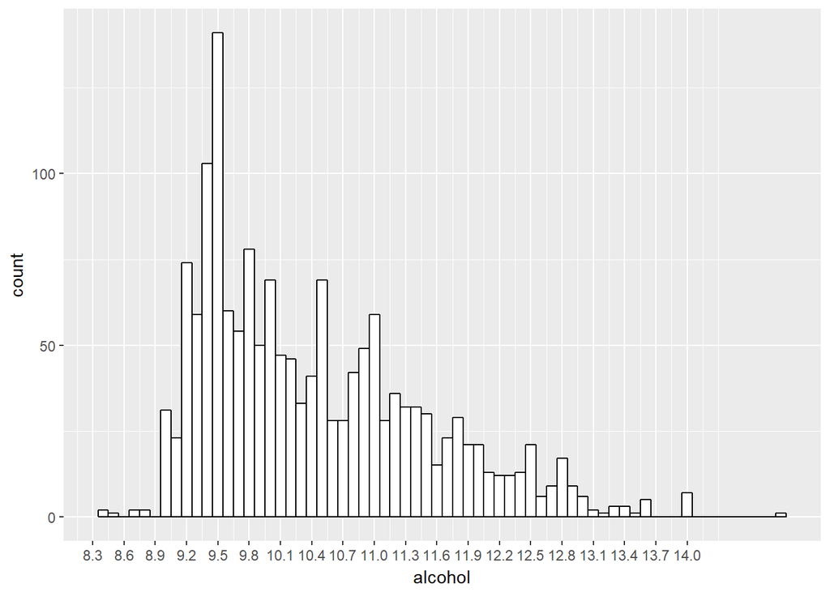

```
## [1] "alcohol"
```

```
##    Min. 1st Qu.  Median    Mean 3rd Qu.    Max.
##    8.40    9.50   10.20   10.42   11.10   14.90
```

The alcohol has an irregular shape distribution.

##### Adding new variables:

residual.sugar_log10 quality.bucket3 dividing the wine quality into 3 groups:

- range [3-4]
- range [5-6]
- range [7-8]

quality.bucket2 dividing wine quality into 2 groups:

- range [0-4]
- range [5-10]

# Univariate Analysis

### What is the structure of your dataset?

We have 1599 observations for different wine samples in the dataset and we have originally 12 features out of which 11 represents the physico-chemical properties of the wine that were collected from lab measurments and all are numerical data. We have the quality rating of the wine that can be considered as a categorical variable obtained based on sensory data ranging from [0-10]

#### pH, density and sulphates

For pH most of the wine data is concentrated between 3.1 and 3.5 and most of observations have a density between 0.995 and 0.998 and a median of 0.9968.

Sulphates has a median 0.622 g/dm^3.

#### Alcohol

median for alcohol around 10.2 g/dm^3 and a peak around 9.4 g/dm^3

### What is/are the main feature(s) of interest in your dataset?

The main feature is the wine quality which is the output variable. This importance is to know which wine properties contrbiutes to the wine quality like:

- Acidity
- Alcohol levels

### What other features in the dataset do you think will help support your investigation into your feature(s) of interest?

Other features to look at is maybe pH levels, density, residual sugar

### Did you create any new variables from existing variables in the dataset?

Yes, I created:

residual.sugar_log10, transforming residual.sugar

quality.bucket3 dividing the wine quality into 3 groups:

- range [3-4]
- range [5-6]
- range [7-8]

quality.bucket2 dividing wine quality into 2 groups:

- range [0-4]
- range [5-10]

trataric_citric adding citric.acid to fixed.acidity

### Of the features you investigated, were there any unusual distributions? Did you perform any operations on the data to tidy, adjust, or change the form of the data? If so, why did you do this?

Fixed acidity, volatile acidity are long tailed. I log transformed the x-axis of the histograms in order to transform the distribution to more symmetric shape and getting rid of few outliers.

Citric acid have strange peak at 0, though I did not appply any modification to remove it.

Residual sugar has a positively skewed distribution; even after transforming to log10 the distribution remained skewed, thus I tried to use breaks on the x-axis to eliminate outliers.

free.suphure,dioxide, total.sulphure.dioxide are both skewed log transformed sulphates and total.sulfure.dioxide to eliminate outliers.

Alcohol has an irregular shaped distribution.

# Bivariate Plots Section

```
##                      fixed.acidity volatile.acidity citric.acid
## fixed.acidity           1.00000000     -0.256130895  0.67170343
## volatile.acidity       -0.25613089      1.000000000 -0.55249568
## citric.acid             0.67170343     -0.552495685  1.00000000
## residual.sugar          0.11477672      0.001917882  0.14357716
## chlorides               0.09370519      0.061297772  0.20382291
## free.sulfur.dioxide    -0.15379419     -0.010503827 -0.06097813
## total.sulfur.dioxide   -0.11318144      0.076470005  0.03553302
## density                 0.66804729      0.022026232  0.36494718
## pH                     -0.68297819      0.234937294 -0.54190414
## sulphates               0.18300566     -0.260986685  0.31277004
## alcohol                -0.06166827     -0.202288027  0.10990325
## quality                 0.12405165     -0.390557780  0.22637251
## tartaric_citric         0.99704157     -0.294847154  0.72665884
## residual.sugar_log10    0.17474165      0.024277851  0.17228587
##                      residual.sugar    chlorides free.sulfur.dioxide
## fixed.acidity           0.114776724  0.093705186        -0.153794193
## volatile.acidity        0.001917882  0.061297772        -0.010503827
## citric.acid             0.143577162  0.203822914        -0.060978129
## residual.sugar          1.000000000  0.055609535         0.187048995
## chlorides               0.055609535  1.000000000         0.005562147
## free.sulfur.dioxide     0.187048995  0.005562147         1.000000000
## total.sulfur.dioxide    0.203027882  0.047400468         0.667666450
## density                 0.355283371  0.200632327        -0.021945831
## pH                     -0.085652422 -0.265026131         0.070377499
## sulphates               0.005527121  0.371260481         0.051657572
## alcohol                 0.042075437 -0.221140545        -0.069408354
## quality                 0.013731637 -0.128906560        -0.050656057
## tartaric_citric         0.121334969  0.108045144        -0.148947646
## residual.sugar_log10    0.932131823  0.044427218         0.150695732
##                      total.sulfur.dioxide     density          pH
## fixed.acidity                 -0.11318144  0.66804729 -0.68297819
## volatile.acidity               0.07647000  0.02202623  0.23493729
## citric.acid                    0.03553302  0.36494718 -0.54190414
## residual.sugar                 0.20302788  0.35528337 -0.08565242
## chlorides                      0.04740047  0.20063233 -0.26502613
## free.sulfur.dioxide            0.66766645 -0.02194583  0.07037750
## total.sulfur.dioxide           1.00000000  0.07126948 -0.06649456
## density                        0.07126948  1.00000000 -0.34169933
## pH                            -0.06649456 -0.34169933  1.00000000
```

[output cut: 20 more lines]

```
##                      residual.sugar_log10
## fixed.acidity                  0.17474165
## volatile.acidity               0.02427785
## citric.acid                    0.17228587
## residual.sugar                 0.93213182
## chlorides                      0.04442722
## free.sulfur.dioxide            0.15069573
## total.sulfur.dioxide           0.19779891
## density                        0.41753813
## pH                            -0.09124113
## sulphates                      0.01058556
## alcohol                        0.08056865
## quality                        0.02353331
## tartaric_citric                0.17992204
## residual.sugar_log10           1.00000000
```

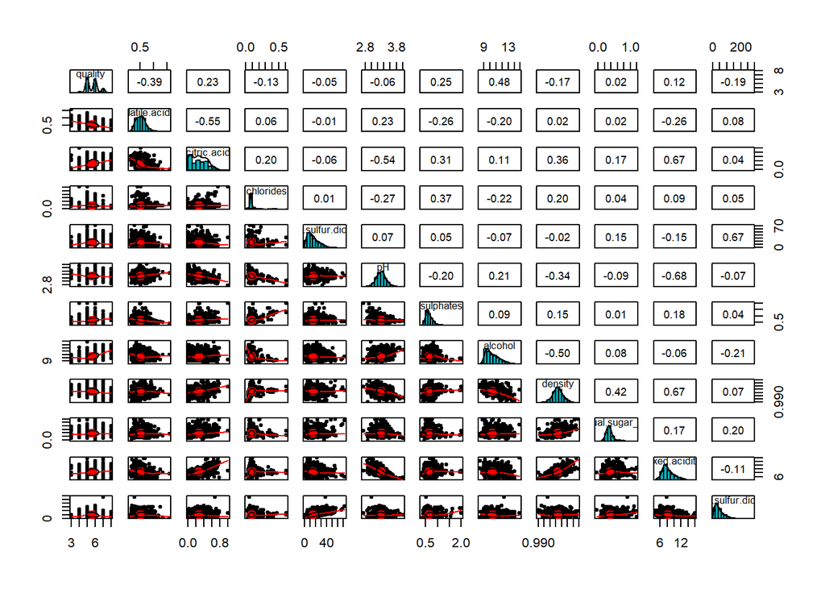

we notice that alcohol has the higher positive correlation with quality. volatile acidity has a negative moderate correlation with quality. citric acid with sulphate both have a weak assoctiation with quality.

There is a negative relationship between citric acid and volatile acid. There is also a negative relationship between citric acid and pH. We have a moderate relationship between sulphates and chlorides. There is a negative moderate relationship between Alcohol and density. and weaker negative relationship between pH and density a positive correlation between fixed acidity and density and weaker positive correlation between density and residual sugar.

##### Let’s explore alcohol vs quality using scatter plot:

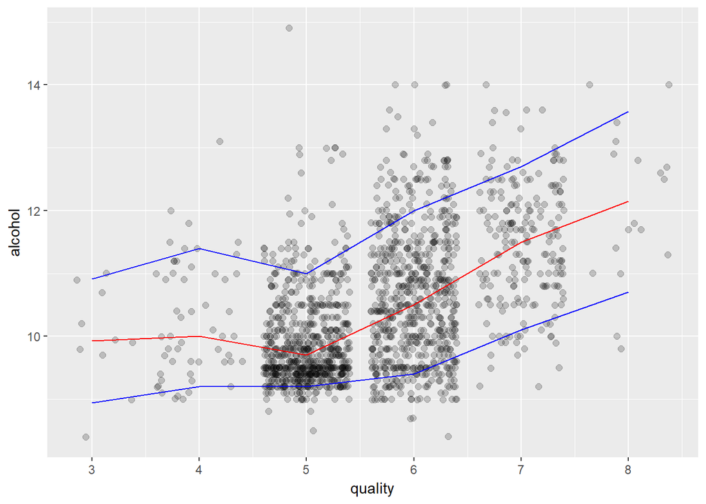

We could see a relationship between increase of alcohol percentage and quality:

- For quality 3-4 90% of alcohol percentage are between 9 and 11.5 g/dm^3
- For quality 7 & 8 90% of alcohol percentage are greater than 10 g/dm^3
- For quality 5 we see a small decrease in the alcohol levels compared to lower quality 4 and 5
- We note that for quality we have a lot of wine observations clustered around 9.4 g/dm^3
- this could explain the peak found around 9.5 in the alcohol histogram
- But there is a clearer positive trend starting from quality level 6

##### Let’s try to explore further why there is a decrease of Alcohol percentage for wine quality 5 by Faceting by wine quality:

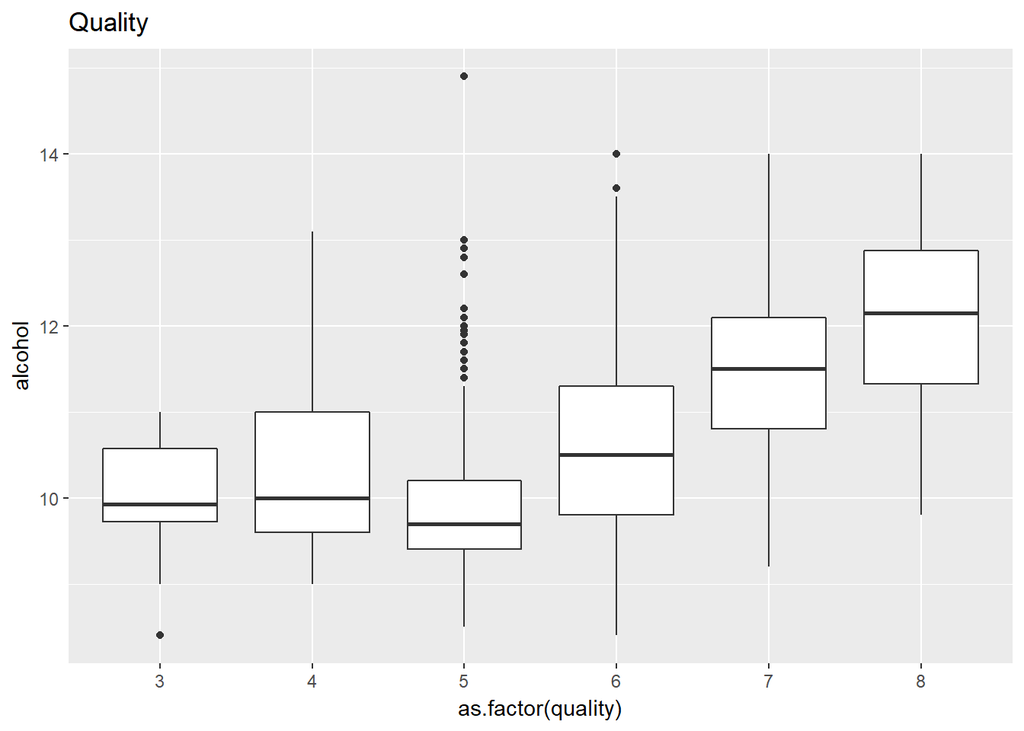

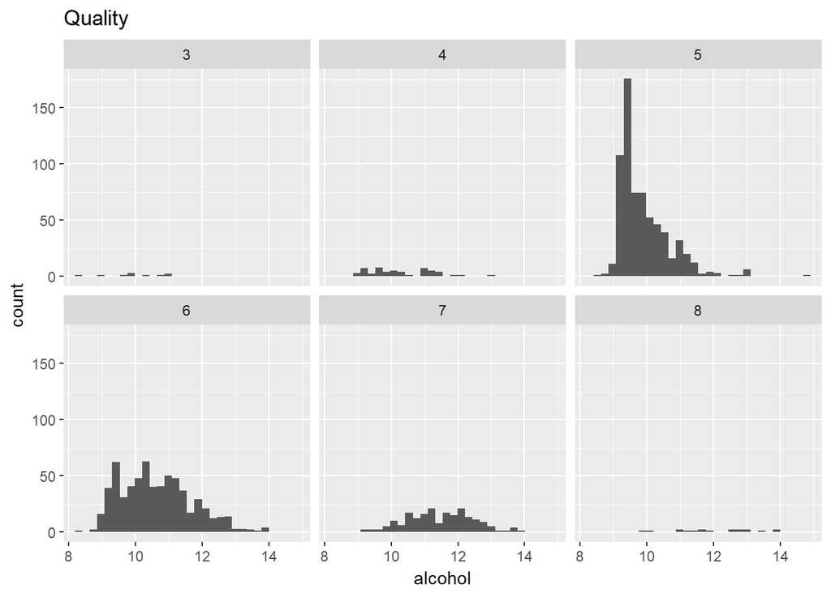

I did not notice this until plotting the scatter plot quality vs alcohol, it looks like alcohol distribution is postively skewed for red wine quality rating 5 and much of the observations are concentrated around 9.5 g/dm^3.

##### Let’s plot volatile.acidity vs quality:

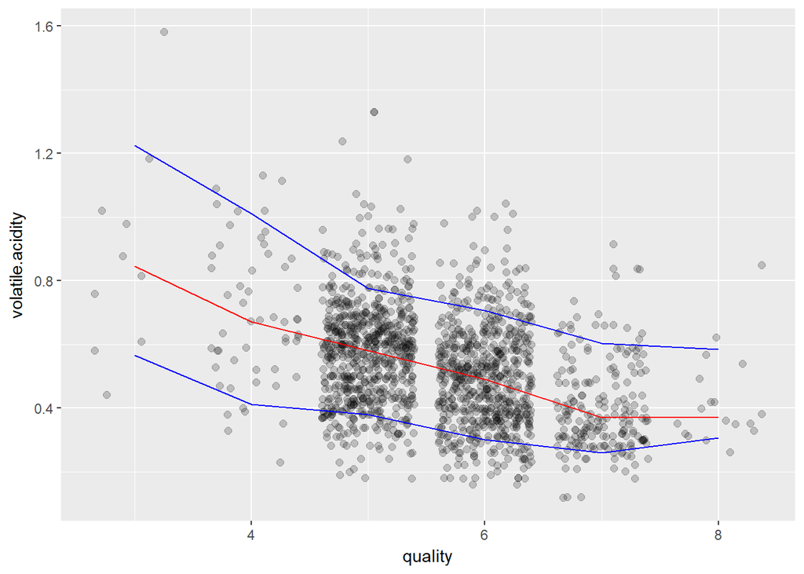

```
## red_wine$quality: 3
##    Min. 1st Qu.  Median    Mean 3rd Qu.    Max.
##  0.4400  0.6475  0.8450  0.8845  1.0100  1.5800
## --------------------------------------------------------
## red_wine$quality: 4
##    Min. 1st Qu.  Median    Mean 3rd Qu.    Max.
##   0.230   0.530   0.670   0.694   0.870   1.130
## --------------------------------------------------------
## red_wine$quality: 5
##    Min. 1st Qu.  Median    Mean 3rd Qu.    Max.
##   0.180   0.460   0.580   0.577   0.670   1.330
## --------------------------------------------------------
## red_wine$quality: 6
##    Min. 1st Qu.  Median    Mean 3rd Qu.    Max.
##  0.1600  0.3800  0.4900  0.4975  0.6000  1.0400
## --------------------------------------------------------
## red_wine$quality: 7
##    Min. 1st Qu.  Median    Mean 3rd Qu.    Max.
##  0.1200  0.3000  0.3700  0.4039  0.4850  0.9150
## --------------------------------------------------------
## red_wine$quality: 8
##    Min. 1st Qu.  Median    Mean 3rd Qu.    Max.
##  0.2600  0.3350  0.3700  0.4233  0.4725  0.8500
```

We can see that there is a negative relationship between between volatile acidity and quality and 90% of the high quality wine have a volatile.acidity less than 0.6 g/dm^3 and a median of below 0.4 g/dm^3. Though the negative trend is not quite significant

##### Now looking at sulphates vs quality and rescaling the y-axis with log10:

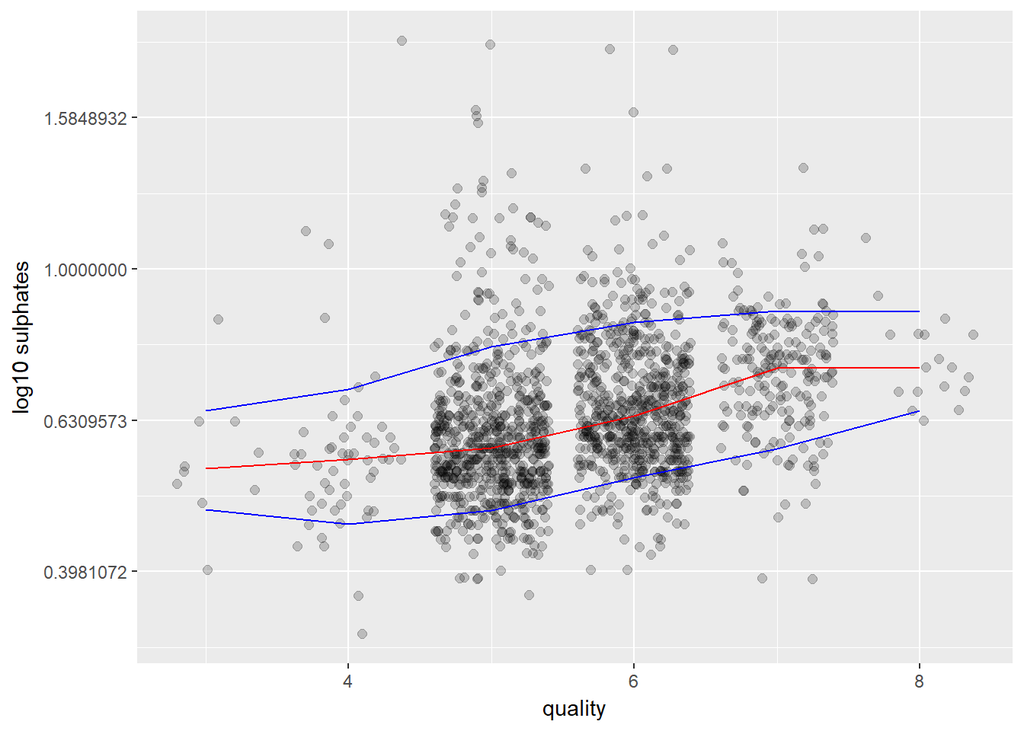

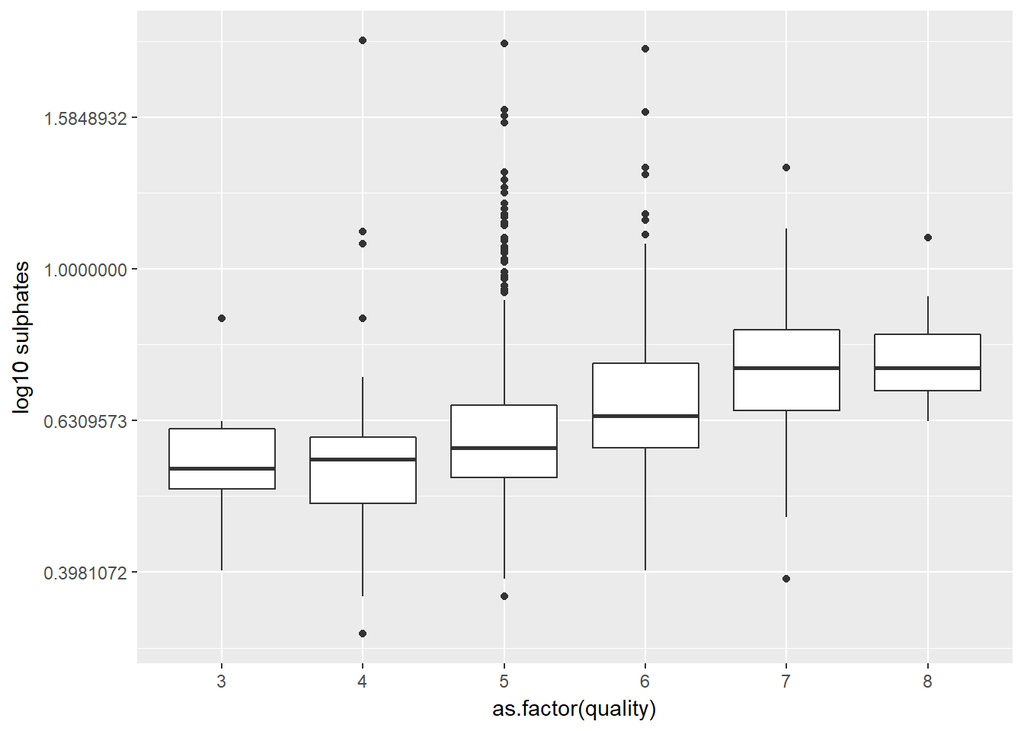

```
## red_wine$quality: 3
##    Min. 1st Qu.  Median    Mean 3rd Qu.    Max.
##  0.4000  0.5125  0.5450  0.5700  0.6150  0.8600
## --------------------------------------------------------
## red_wine$quality: 4
##    Min. 1st Qu.  Median    Mean 3rd Qu.    Max.
##  0.3300  0.4900  0.5600  0.5964  0.6000  2.0000
## --------------------------------------------------------
## red_wine$quality: 5
##    Min. 1st Qu.  Median    Mean 3rd Qu.    Max.
##   0.370   0.530   0.580   0.621   0.660   1.980
## --------------------------------------------------------
## red_wine$quality: 6
##    Min. 1st Qu.  Median    Mean 3rd Qu.    Max.
##  0.4000  0.5800  0.6400  0.6753  0.7500  1.9500
## --------------------------------------------------------
## red_wine$quality: 7
##    Min. 1st Qu.  Median    Mean 3rd Qu.    Max.
##  0.3900  0.6500  0.7400  0.7413  0.8300  1.3600
## --------------------------------------------------------
## red_wine$quality: 8
##    Min. 1st Qu.  Median    Mean 3rd Qu.    Max.
##  0.6300  0.6900  0.7400  0.7678  0.8200  1.1000
```

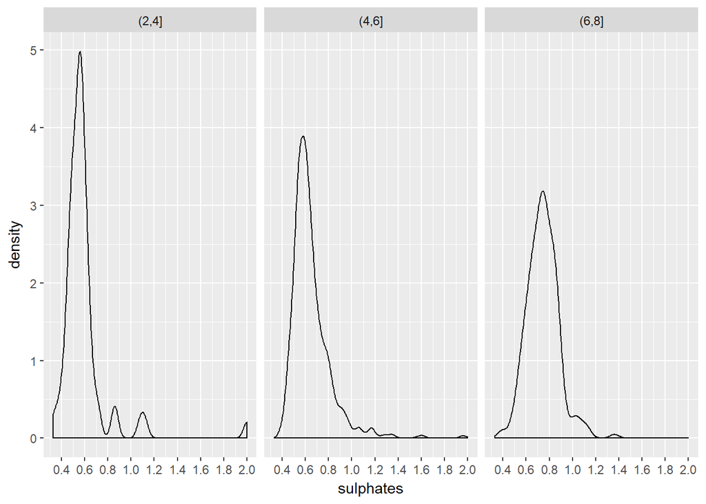

It appears also that there is a positive trend, when sulphates increases the wine quality increases. Though we can spot few outliers for wine quality of 4 and 5. The low wine quality have a median of 0.55 g/dm^3 while high wine quality 7-8 have median 0.74 g/dm^3

##### Now let’s look at citric.acid vs quality:

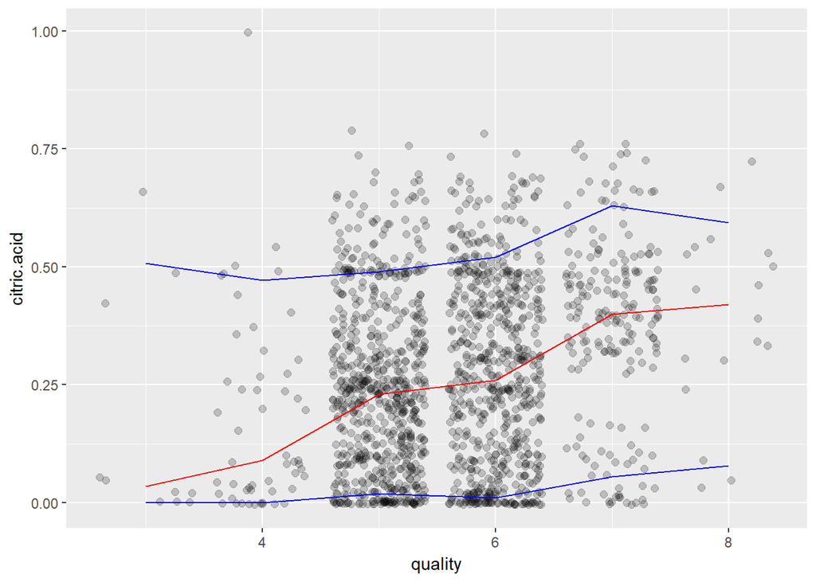

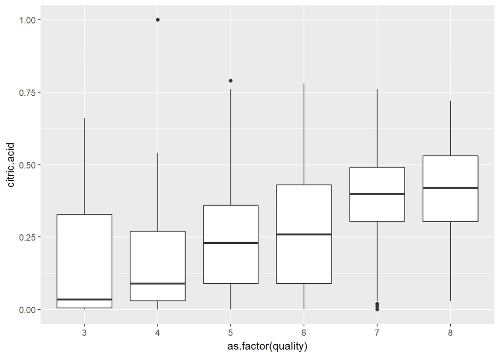

```
## red_wine$quality: 3
##    Min. 1st Qu.  Median    Mean 3rd Qu.    Max.
##  0.0000  0.0050  0.0350  0.1710  0.3275  0.6600
## --------------------------------------------------------
## red_wine$quality: 4
##    Min. 1st Qu.  Median    Mean 3rd Qu.    Max.
##  0.0000  0.0300  0.0900  0.1742  0.2700  1.0000
## --------------------------------------------------------
## red_wine$quality: 5
##    Min. 1st Qu.  Median    Mean 3rd Qu.    Max.
##  0.0000  0.0900  0.2300  0.2437  0.3600  0.7900
## --------------------------------------------------------
## red_wine$quality: 6
##    Min. 1st Qu.  Median    Mean 3rd Qu.    Max.
##  0.0000  0.0900  0.2600  0.2738  0.4300  0.7800
## --------------------------------------------------------
## red_wine$quality: 7
##    Min. 1st Qu.  Median    Mean 3rd Qu.    Max.
##  0.0000  0.3050  0.4000  0.3752  0.4900  0.7600
## --------------------------------------------------------
## red_wine$quality: 8
##    Min. 1st Qu.  Median    Mean 3rd Qu.    Max.
##  0.0300  0.3025  0.4200  0.3911  0.5300  0.7200
```

Higher quality wine ratings appear to have slightly higer concentration of citric acid whith wine quality 8 have a median of 0.4200 compared to 0.0900 for a quality 4.

##### Let’s check the relationship quality vs density:

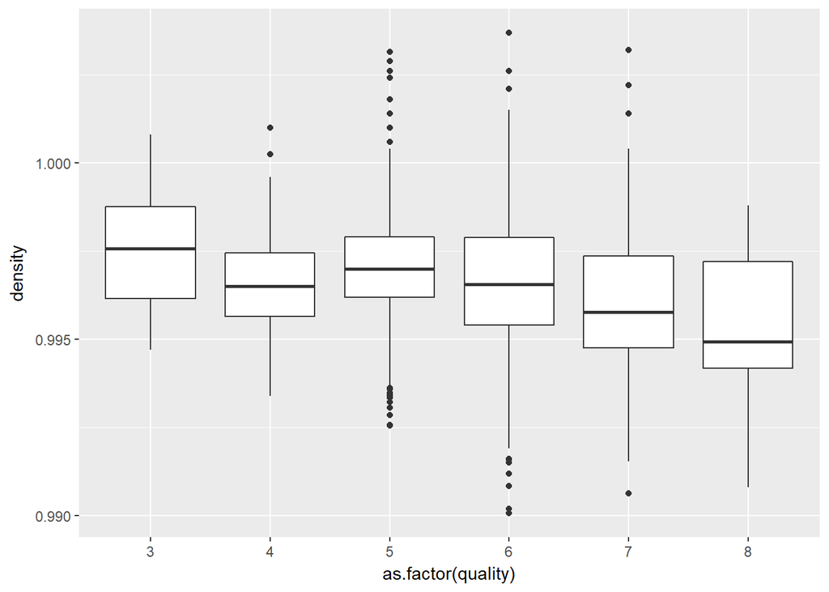

It appears that wine with higher quality tend to have less density. But the relationship is weak and this appears from the box plot and the median summary.

From the correlation matrix there is a relationship between density:

- Alcohol percentage
- fixed.acidity
- residual.sugar

##### Let’s draw a scatter plots:

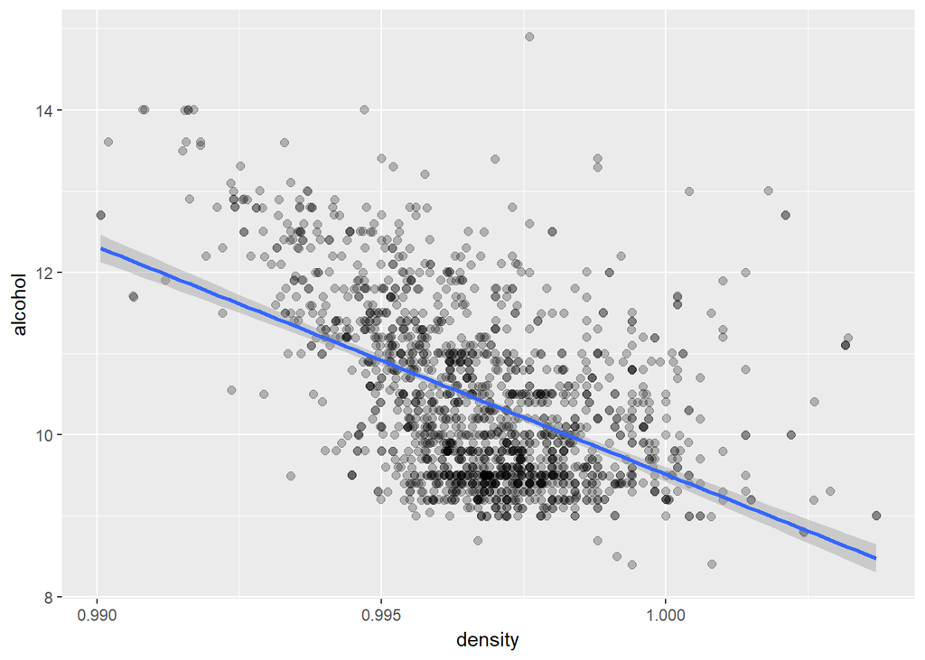

We can see that density is negatively correlated to alcohol percentage which is logical. With most of observation is clustered between 0.995 and 0.998 g/dm^3. That would explain why higher quality wine tend to have lower densities.

##### Let’s check fixed.acidity vs density:

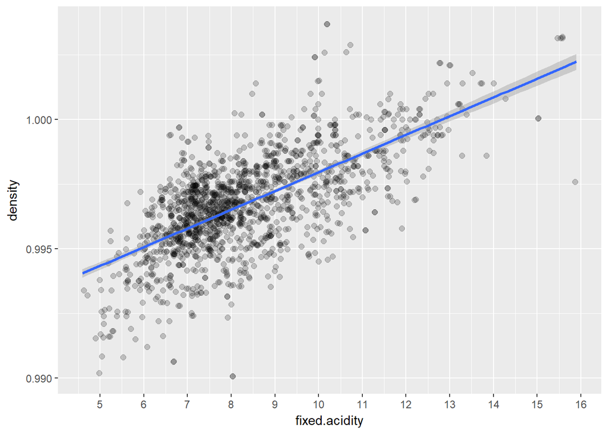

We see that denstiy increases when the fixed acidity level increases.

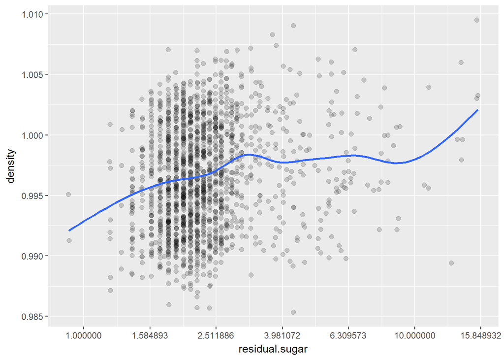

Nothing much from this plot residual sugar distribution is positvely skewed with the most of the data clustered between 1.58 and 2.5 g/dm^3. Rescaling the x-axis using log10, we notice a very weak positive correlation between residual sugar levels and density and it appear that we have stripes which indicates that we have measurments many observations having same measurments.

##### relationship fixed acidity vs citric acid:

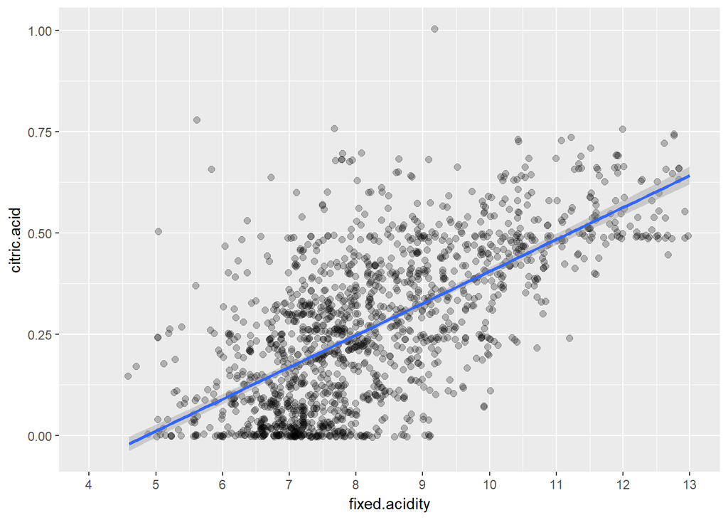

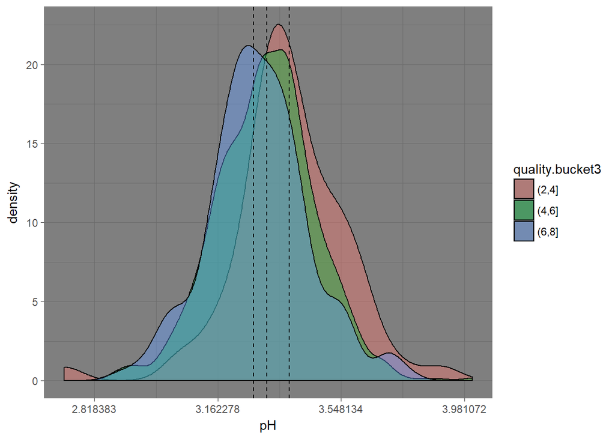

```
## red_wine$quality: 3
##    Min. 1st Qu.  Median    Mean 3rd Qu.    Max.
##   3.160   3.312   3.390   3.398   3.495   3.630
## --------------------------------------------------------
## red_wine$quality: 4
##    Min. 1st Qu.  Median    Mean 3rd Qu.    Max.
##   2.740   3.300   3.370   3.382   3.500   3.900
## --------------------------------------------------------
## red_wine$quality: 5
##    Min. 1st Qu.  Median    Mean 3rd Qu.    Max.
##   2.880   3.200   3.300   3.305   3.400   3.740
## --------------------------------------------------------
## red_wine$quality: 6
##    Min. 1st Qu.  Median    Mean 3rd Qu.    Max.
##   2.860   3.220   3.320   3.318   3.410   4.010
## --------------------------------------------------------
## red_wine$quality: 7
##    Min. 1st Qu.  Median    Mean 3rd Qu.    Max.
##   2.920   3.200   3.280   3.291   3.380   3.780
## --------------------------------------------------------
## red_wine$quality: 8
##    Min. 1st Qu.  Median    Mean 3rd Qu.    Max.
##   2.880   3.163   3.230   3.267   3.350   3.720
```

It appears that pH level slightly decreases with higher quality wine, as this could be related to higher acidity concentrations found in higher quality wines as acidity is one of the major factors that affects pH levels.